# BIOSTAT 203B Homework 2

Due Friday, 2/7 @ 11:59 PM

Tony Lim

Use tidyverse (ggpot2, dplyr) to explore the [MIMIC-III](https://mimic.physionet.org) data introduced in [homework 1](https://ucla-biostat203b-2020winter.github.io/hw/hw1/hw1.html).

## Q1

Demographic information of the patients admitted into hospital is available in `ADMISSION.csv`. See https://mimic.physionet.org/mimictables/admissions/ for details of each field in this file. Summarize following variables using appropriate graphs:

- admission year
- admission month
- admission week day
- admission hour
- length of hospital stay
- admission type
- number of admissions per patient
- admission location
- insurance
- language
- religion
- martial status
- ethnicity
- death

Note it is possible that one patient (uniquely identified by the `SUBJECT_ID`) is admitted into hospital multiple times. When summarizing some demographic information, it makes sense to summarize based on only unique patients.

### Prerequisities

Load tidyverse and lubridate:

```r
library(tidyverse)
library(lubridate)
```

```bash
head /home/203bdata/mimic-iii/ADMISSIONS.csv
```

```
## "ROW_ID","SUBJECT_ID","HADM_ID","ADMITTIME","DISCHTIME","DEATHTIME","ADMISSION_TYPE","ADMISSION_LOCATION","DISCHARGE_LOCATION","INSURANCE","LANGUAGE","RELIGION","MARITAL_STATUS","ETHNICITY","EDREGTIME","EDOUTTIME","DIAGNOSIS","HOSPITAL_EXPIRE_FLAG","HAS_CHARTEVENTS_DATA"
## 21,22,165315,2196-04-09 12:26:00,2196-04-10 15:54:00,,"EMERGENCY","EMERGENCY ROOM ADMIT","DISC-TRAN CANCER/CHLDRN H","Private",,"UNOBTAINABLE","MARRIED","WHITE",2196-04-09 10:06:00,2196-04-09 13:24:00,"BENZODIAZEPINE OVERDOSE",0,1
## 22,23,152223,2153-09-03 07:15:00,2153-09-08 19:10:00,,"ELECTIVE","PHYS REFERRAL/NORMAL DELI","HOME HEALTH CARE","Medicare",,"CATHOLIC","MARRIED","WHITE",,,"CORONARY ARTERY DISEASE\CORONARY ARTERY BYPASS GRAFT/SDA",0,1
## 23,23,124321,2157-10-18 19:34:00,2157-10-25 14:00:00,,"EMERGENCY","TRANSFER FROM HOSP/EXTRAM","HOME HEALTH CARE","Medicare","ENGL","CATHOLIC","MARRIED","WHITE",,,"BRAIN MASS",0,1
## 24,24,161859,2139-06-06 16:14:00,2139-06-09 12:48:00,,"EMERGENCY","TRANSFER FROM HOSP/EXTRAM","HOME","Private",,"PROTESTANT QUAKER","SINGLE","WHITE",,,"INTERIOR MYOCARDIAL INFARCTION",0,1
## 25,25,129635,2160-11-02 02:06:00,2160-11-05 14:55:00,,"EMERGENCY","EMERGENCY ROOM ADMIT","HOME","Private",,"UNOBTAINABLE","MARRIED","WHITE",2160-11-02 01:01:00,2160-11-02 04:27:00,"ACUTE CORONARY SYNDROME",0,1
## 26,26,197661,2126-05-06 15:16:00,2126-05-13 15:00:00,,"EMERGENCY","TRANSFER FROM HOSP/EXTRAM","HOME","Medicare",,"CATHOLIC","SINGLE","UNKNOWN/NOT SPECIFIED",,,"V-TACH",0,1
## 27,27,134931,2191-11-30 22:16:00,2191-12-03 14:45:00,,"NEWBORN","PHYS REFERRAL/NORMAL DELI","HOME","Private",,"CATHOLIC",,"WHITE",,,"NEWBORN",0,1
## 28,28,162569,2177-09-01 07:15:00,2177-09-06 16:00:00,,"ELECTIVE","PHYS REFERRAL/NORMAL DELI","HOME HEALTH CARE","Medicare",,"CATHOLIC","MARRIED","WHITE",,,"CORONARY ARTERY DISEASE\CORONARY ARTERY BYPASS GRAFT/SDA",0,1
## 29,30,104557,2172-10-14 14:17:00,2172-10-19 14:37:00,,"URGENT","TRANSFER FROM HOSP/EXTRAM","HOME HEALTH CARE","Medicare",,"CATHOLIC","MARRIED","UNKNOWN/NOT SPECIFIED",,,"UNSTABLE ANGINA\CATH",0,1
```

```r
admissions <- read_csv("/home/203bdata/mimic-iii/ADMISSIONS.csv")
admissions %>% print(width = Inf)
```

```
## # A tibble: 58,976 x 19
##    ROW_ID SUBJECT_ID HADM_ID ADMITTIME           DISCHTIME
##     <dbl>      <dbl>   <dbl> <dttm>              <dttm>
##  1     21         22  165315 2196-04-09 12:26:00 2196-04-10 15:54:00
##  2     22         23  152223 2153-09-03 07:15:00 2153-09-08 19:10:00
##  3     23         23  124321 2157-10-18 19:34:00 2157-10-25 14:00:00
##  4     24         24  161859 2139-06-06 16:14:00 2139-06-09 12:48:00
##  5     25         25  129635 2160-11-02 02:06:00 2160-11-05 14:55:00
##  6     26         26  197661 2126-05-06 15:16:00 2126-05-13 15:00:00
##  7     27         27  134931 2191-11-30 22:16:00 2191-12-03 14:45:00
##  8     28         28  162569 2177-09-01 07:15:00 2177-09-06 16:00:00
##  9     29         30  104557 2172-10-14 14:17:00 2172-10-19 14:37:00
## 10     30         31  128652 2108-08-22 23:27:00 2108-08-30 15:00:00
##    DEATHTIME           ADMISSION_TYPE ADMISSION_LOCATION
##    <dttm>              <chr>          <chr>
```

[output cut: 59 more lines]

```r
admissions <- read_csv("/home/203bdata/mimic-iii/ADMISSIONS.csv",
                      col_types = cols(ROW_ID = col_integer(),
                                       SUBJECT_ID = col_integer(),
                                       HADM_ID = col_integer(),
                                       HOSPITAL_EXPIRE_FLAG = col_logical(),
                                       HAS_CHARTEVENTS_DATA = col_logical()))

admissions %>% print(width = Inf)
```

```
## # A tibble: 58,976 x 19
##    ROW_ID SUBJECT_ID HADM_ID ADMITTIME           DISCHTIME
##     <int>      <int>   <int> <dttm>              <dttm>
##  1     21         22  165315 2196-04-09 12:26:00 2196-04-10 15:54:00
##  2     22         23  152223 2153-09-03 07:15:00 2153-09-08 19:10:00
##  3     23         23  124321 2157-10-18 19:34:00 2157-10-25 14:00:00
##  4     24         24  161859 2139-06-06 16:14:00 2139-06-09 12:48:00
##  5     25         25  129635 2160-11-02 02:06:00 2160-11-05 14:55:00
##  6     26         26  197661 2126-05-06 15:16:00 2126-05-13 15:00:00
##  7     27         27  134931 2191-11-30 22:16:00 2191-12-03 14:45:00
##  8     28         28  162569 2177-09-01 07:15:00 2177-09-06 16:00:00
##  9     29         30  104557 2172-10-14 14:17:00 2172-10-19 14:37:00
## 10     30         31  128652 2108-08-22 23:27:00 2108-08-30 15:00:00
##    DEATHTIME           ADMISSION_TYPE ADMISSION_LOCATION
##    <dttm>              <chr>          <chr>
```

[output cut: 59 more lines]

### Admission year

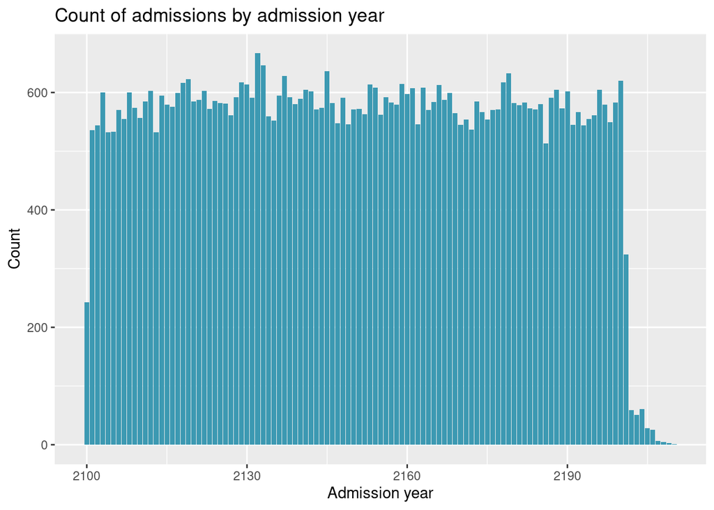

```r
admissions %>%
  mutate(adm_year = year(ADMITTIME)) %>%
  ggplot() +
  geom_bar(mapping = aes(x = adm_year), fill = "#3C99B2") +
  ggtitle("Count of admissions by admission year") +
  xlab("Admission year") +
  ylab("Count")
```

### Admission month

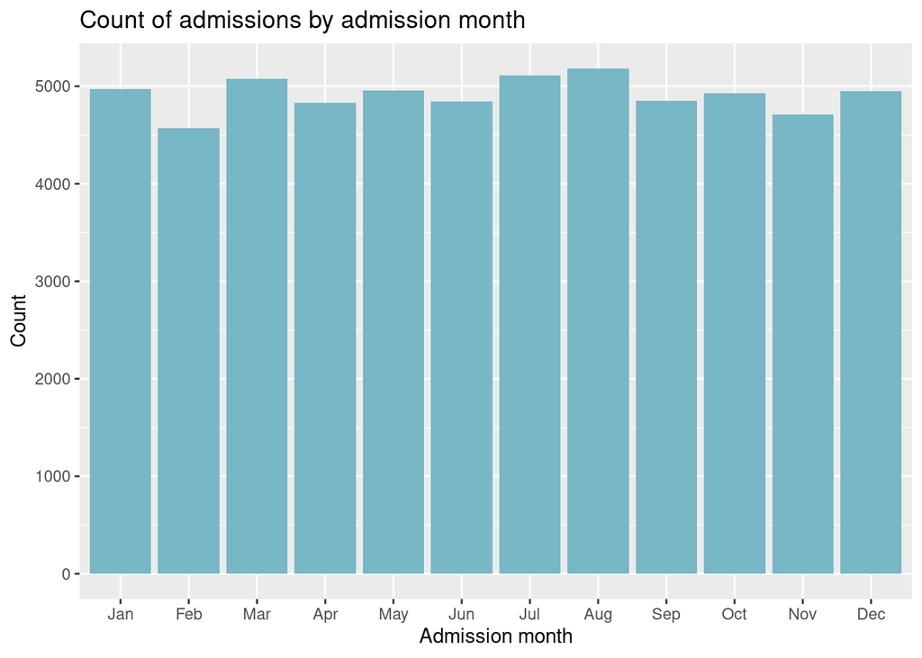

```r
admissions %>%
  mutate(adm_month = month(ADMITTIME, label = TRUE)) %>%
  ggplot() +
  geom_bar(mapping = aes(x = adm_month), fill = "#78b7c5") +
  ggtitle("Count of admissions by admission month") +
  xlab("Admission month") +
  ylab("Count")
```

There does not appear to be a significant difference in the number of admissions when examining by month.

### Admission week day

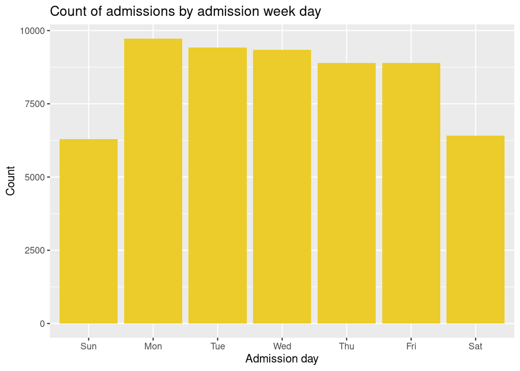

```r
admissions %>%
  mutate(adm_weekdays = wday(ADMITTIME, label = TRUE)) %>%
  ggplot() +
  geom_bar(mapping = aes(x = adm_weekdays), fill = "#EBCC2A") +
  ggtitle("Count of admissions by admission week day") +
  xlab("Admission day") +
  ylab("Count")
```

The weekend (Saturday and Sunday) appears to lower total admission counts than the weekdays.

### Admission hour

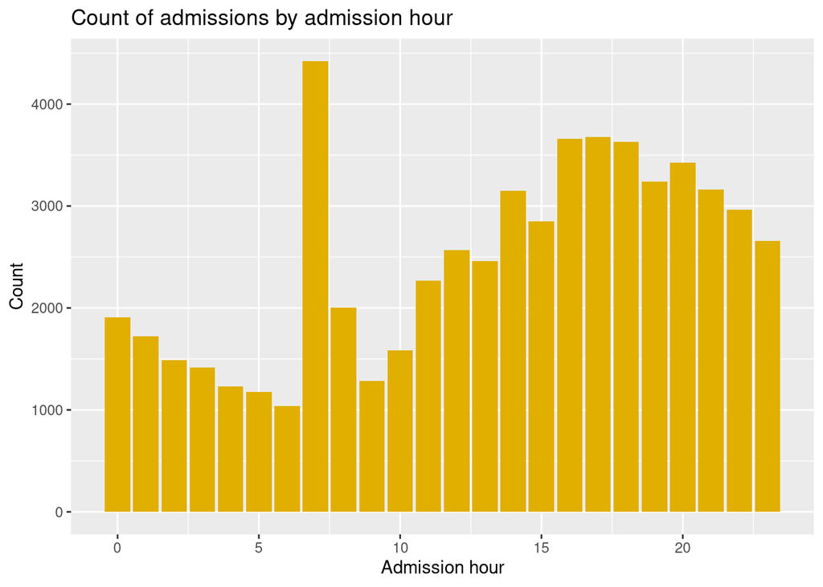

```r
admissions %>%
  mutate(adm_hour = hour(ADMITTIME)) %>%
  ggplot() +
  geom_bar(mapping = aes(x = adm_hour), fill = "#E1AF00") +
  ggtitle("Count of admissions by admission hour") +
  xlab("Admission hour") +
  ylab("Count")
```

It appears there is a spike in admission count at 7:00 AM. This may be the hospitals’ opening time, and some patients may want to be seen as soon as possible if they experience something overnight.

### Admission minute

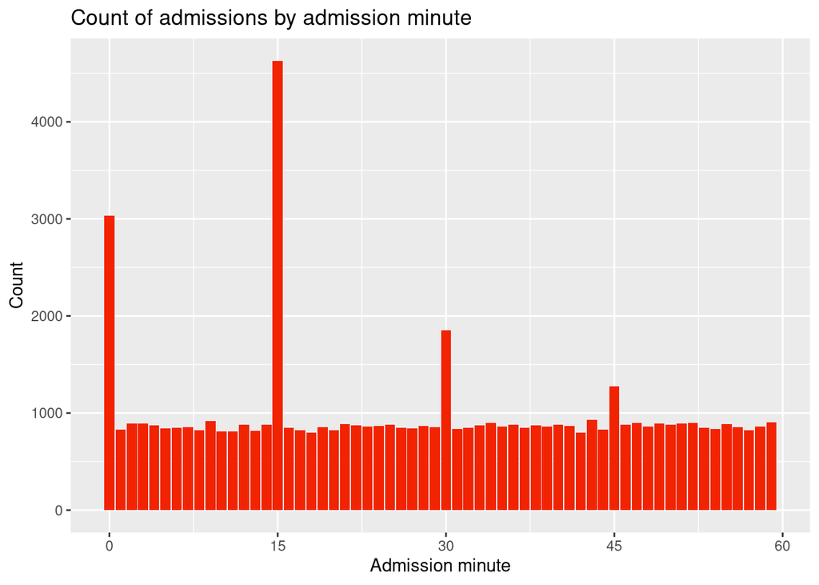

```r
admissions %>%
  mutate(adm_min = minute(ADMITTIME)) %>%
  ggplot() +
  geom_bar(mapping = aes(x = adm_min), fill = "#F22300") +
  ggtitle("Count of admissions by admission minute") +
  xlab("Admission minute") +
  ylab("Count") +
  scale_x_continuous(breaks = c(0, 15, 30, 45, 60))
```

It appears there are spikes in admission count at 15/30/45 minutes. This may be due to nurses rounding the time when they manually entering data for `ADMITTIME`.

### Length of hospital stay

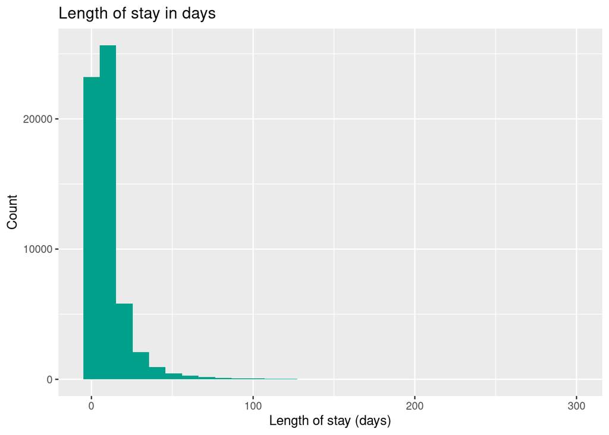

```r
admissions %>%
  mutate(los_days = as.numeric(as.duration(DISCHTIME - ADMITTIME) / 86400)) %>%
  ggplot() +
  geom_histogram(mapping = aes(x = los_days), fill = "#01A08A") +
  ggtitle("Length of stay in days") +
  xlab("Length of stay (days)") +
  ylab("Count")
```

The longest length of stay is 294.66 days, which seems like an extremely long period. However, because the data has been extended, it is possible the longest length of stay should be around 26 days (294.66/11.33).

### Admission type

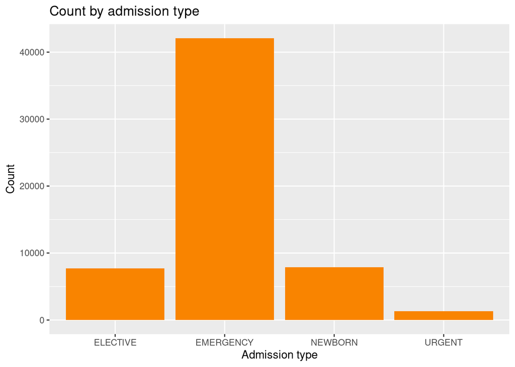

```r
admissions %>%
  ggplot() +
  geom_bar(mapping = aes(x = ADMISSION_TYPE), fill = "#F98400") +
  ggtitle("Count by admission type") +
  xlab("Admission type") +
  ylab("Count")
```

A large majority of admissions fall under the Emergency category.

### Number of admissions per patient

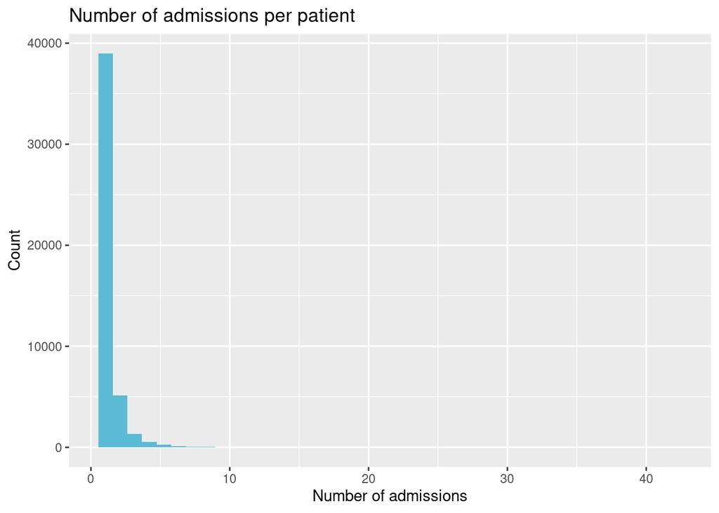

```r
admissions %>%
  group_by(SUBJECT_ID) %>%
  dplyr::summarise(n = n()) %>%
  arrange(desc(n)) %>%
  ggplot() +
  geom_histogram(mapping = aes(x = n), fill = "#5BBBD5", bins = 40) +
  labs(title = "Number of admissions per patient",
       x = "Number of admissions",
       y = "Count")
```

The majority of patients have only have one admission to the hospital. However, some patients are heavy utilizers, skewing the histogram to the right. For example, Subject 13033 has a total of 42 admissions.

### Admission location

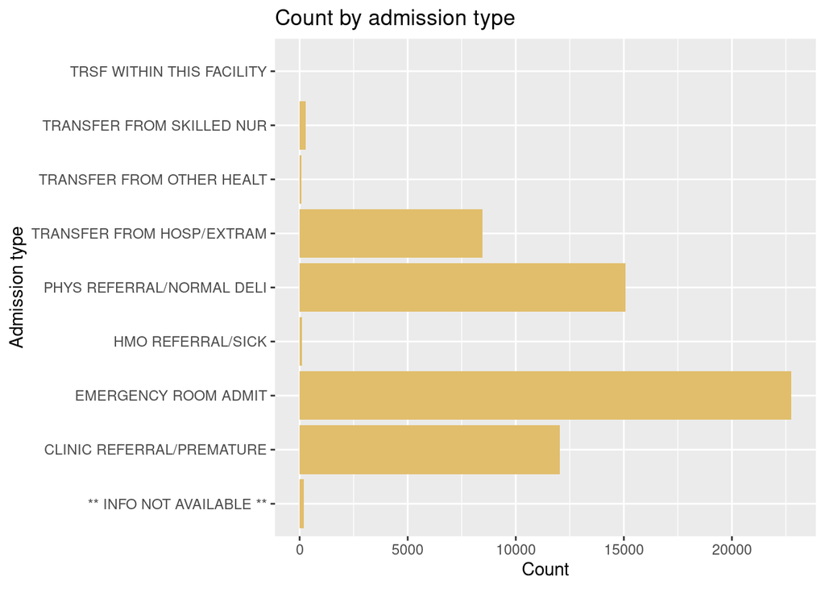

```r
admissions %>%
  ggplot() +
  geom_bar(mapping = aes(x = ADMISSION_LOCATION), fill = "#E1BE6C") +
  ggtitle("Count by admission type") +
  xlab("Admission type") +
  ylab("Count") +
  coord_flip()
```

The most common previous locations of the patient prior to arriving at the hospital includes ER admit, Physician referral/normal delivery, Clinic referral, and Transfer from hospital.

### Insurance

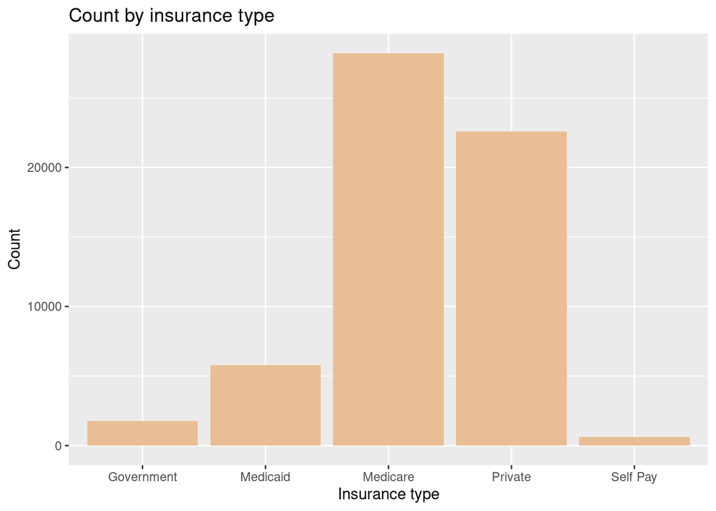

```r
admissions %>%
  ggplot() +
  geom_bar(mapping = aes(x = INSURANCE), fill = "#EABE94") +
  ggtitle("Count by insurance type") +
  xlab("Insurance type") +
  ylab("Count")
```

The most common form of insurance is Medicare following by private insurance.

### Language

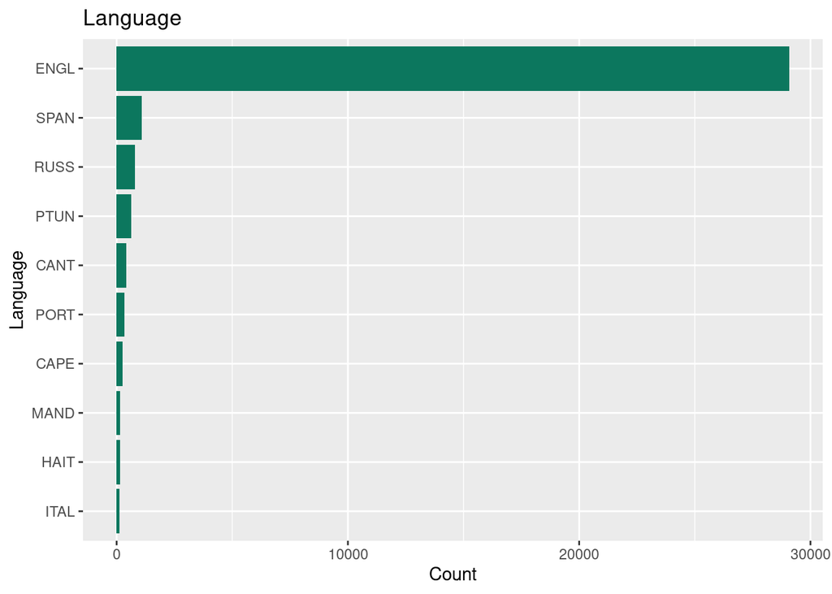

```r
admissions %>%
  plyr::count("LANGUAGE") %>%
  arrange(desc(freq)) %>%
  drop_na(LANGUAGE) %>%
  filter(rank(desc(freq)) < 11) %>%
  ggplot() +
  geom_bar(mapping = aes(x = reorder(LANGUAGE, freq), y = freq),
           stat = "identity",
           fill = "#0C775E") +
  ggtitle("Language") +
  xlab("Language") +
  ylab("Count") +
  coord_flip()
```

English is the most common language.

Note: there are 25,332 counts of NA omitted from the bar plot.

### Religion

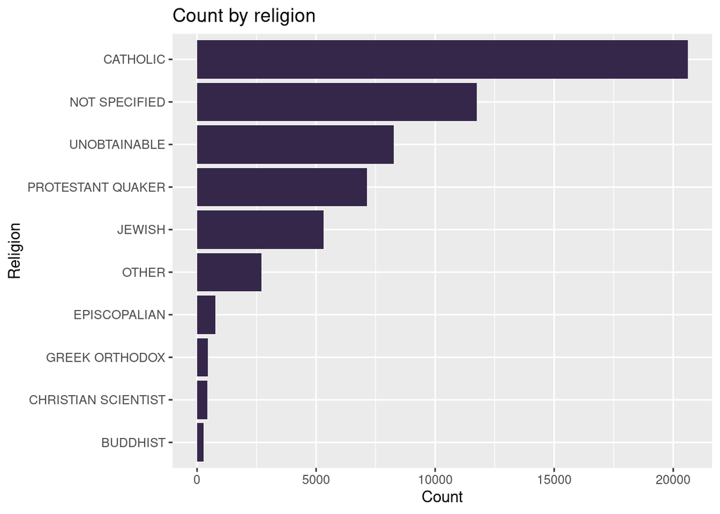

```r
admissions %>%
  plyr::count("RELIGION") %>%
  arrange(desc(freq)) %>%
  drop_na(RELIGION) %>%
  filter(rank(desc(freq)) < 11) %>%
  ggplot() +
  geom_bar(mapping = aes(x = reorder(RELIGION, freq), y = freq),
           stat = "identity",
           fill = "#35274A") +
  ggtitle("Count by religion") +
  xlab("Religion") +
  ylab("Count") +
  coord_flip()
```

The most common religion among patients is Catholicism. Many patients have Not specified (11,753) or Unobtainable (8,269) for their religion.

### Martial status

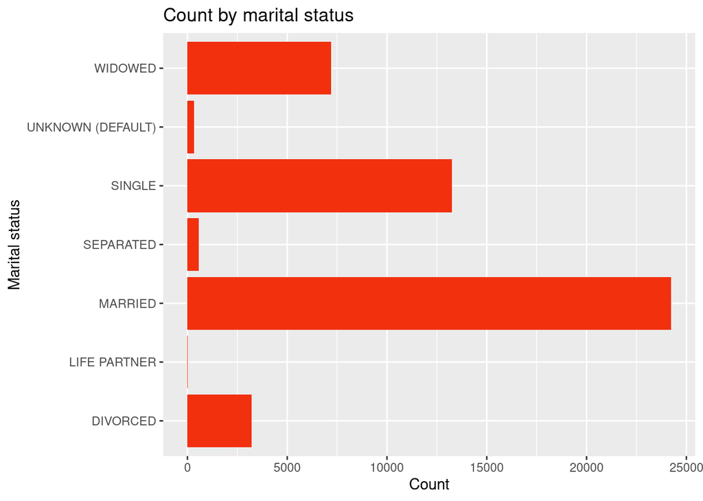

```r
admissions %>%
  drop_na(MARITAL_STATUS) %>%
  ggplot() +
  geom_bar(mapping = aes(x = MARITAL_STATUS), fill = "#F2300E") +
  ggtitle("Count by marital status") +
  xlab("Marital status") +
  ylab("Count") +
  coord_flip()
```

Regarding marital status, the most common category is Married followed by Single and then Widowed.

### Ethnicity

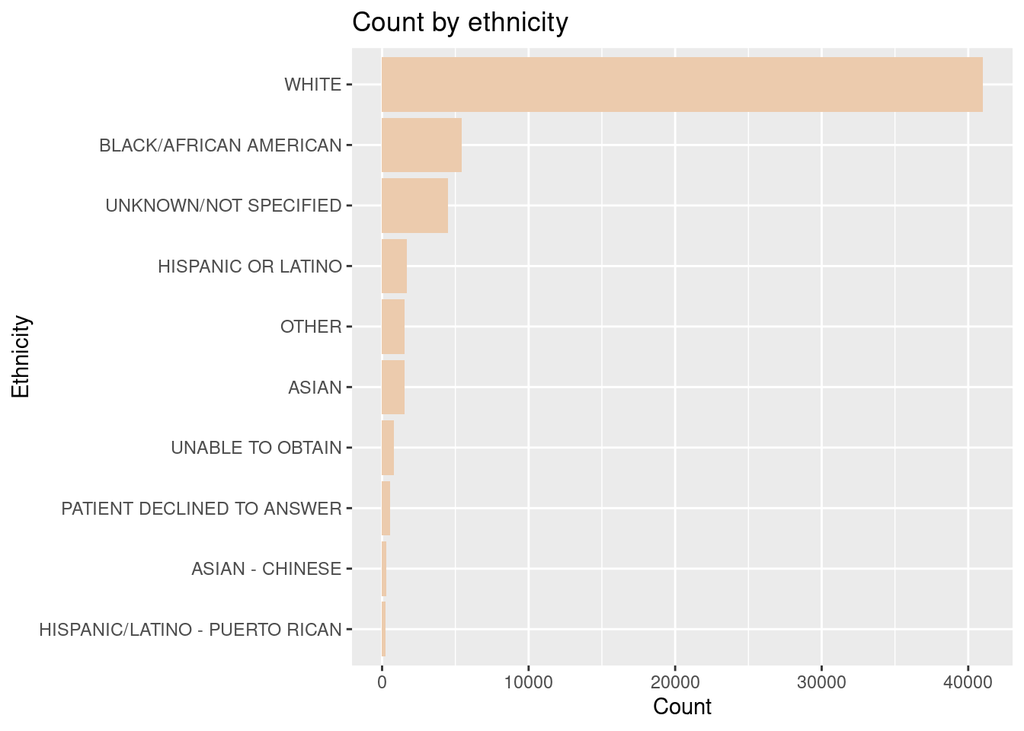

```r
admissions %>%
  plyr::count("ETHNICITY") %>%
  arrange(desc(freq)) %>%
  filter(rank(desc(freq)) < 11) %>%
  ggplot() +
  geom_bar(mapping = aes(x = reorder(ETHNICITY, freq), y = freq),
           stat = "identity",
           fill = "#ECCBAD") +
  ggtitle("Count by ethnicity") +
  xlab("Ethnicity") +
  ylab("Count") +
  coord_flip()
```

The most common ethnicity category is White followed by Black/African American.

### Death

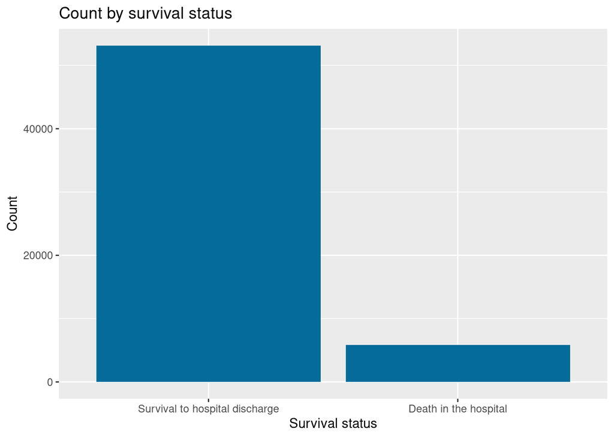

```r
admissions %>%
  ggplot() +
  geom_bar(mapping = aes(x = HOSPITAL_EXPIRE_FLAG), fill = "#056C9A") +
  ggtitle("Count by survival status") +
  xlab("Survival status") +
  ylab("Count") +
  scale_x_discrete(labels = c("FALSE" = "Survival to hospital discharge",
                              "TRUE" = "Death in the hospital"))
```

```r
admissions %>%
  group_by(HOSPITAL_EXPIRE_FLAG) %>%
  dplyr::summarise(n = n()) %>%
  arrange(desc(n)) %>%
  dplyr::rename(Survival = HOSPITAL_EXPIRE_FLAG, Count = n)
```

```
## # A tibble: 2 x 2
##   Survival Count
##   <lgl>    <int>
## 1 FALSE    53122
## 2 TRUE      5854
```

Almost 10% of patients do not survive to hospital discharge.

## Q2

Link the data in `ADMISSION.csv` and `PATIENTS.csv` (https://mimic.physionet.org/mimictables/patients/) and summarize following variables using appropriate graphs:

- gender
- age at admission

```r
admissions <- read_csv("/home/203bdata/mimic-iii/ADMISSIONS.csv",
                      col_types = cols(ROW_ID = col_integer(),
                                       SUBJECT_ID = col_integer(),
                                       HADM_ID = col_integer(),
                                       HOSPITAL_EXPIRE_FLAG = col_logical(),
                                       HAS_CHARTEVENTS_DATA = col_logical()))

patients <- read_csv("/home/203bdata/mimic-iii/PATIENTS.csv")
combine <- inner_join(admissions, patients, by = "SUBJECT_ID")
combine %>% print(width = Inf)
```

```
## # A tibble: 58,976 x 26
##    ROW_ID.x SUBJECT_ID HADM_ID ADMITTIME           DISCHTIME
##       <int>      <dbl>   <int> <dttm>              <dttm>
##  1       21         22  165315 2196-04-09 12:26:00 2196-04-10 15:54:00
##  2       22         23  152223 2153-09-03 07:15:00 2153-09-08 19:10:00
##  3       23         23  124321 2157-10-18 19:34:00 2157-10-25 14:00:00
##  4       24         24  161859 2139-06-06 16:14:00 2139-06-09 12:48:00
##  5       25         25  129635 2160-11-02 02:06:00 2160-11-05 14:55:00
##  6       26         26  197661 2126-05-06 15:16:00 2126-05-13 15:00:00
##  7       27         27  134931 2191-11-30 22:16:00 2191-12-03 14:45:00
##  8       28         28  162569 2177-09-01 07:15:00 2177-09-06 16:00:00
##  9       29         30  104557 2172-10-14 14:17:00 2172-10-19 14:37:00
## 10       30         31  128652 2108-08-22 23:27:00 2108-08-30 15:00:00
##    DEATHTIME           ADMISSION_TYPE ADMISSION_LOCATION
##    <dttm>              <chr>          <chr>
```

[output cut: 71 more lines]

`combine` is created by doing an `inner_join` between `ADMISSIONS.csv` and `PATIENTS.csv`.

### Gender

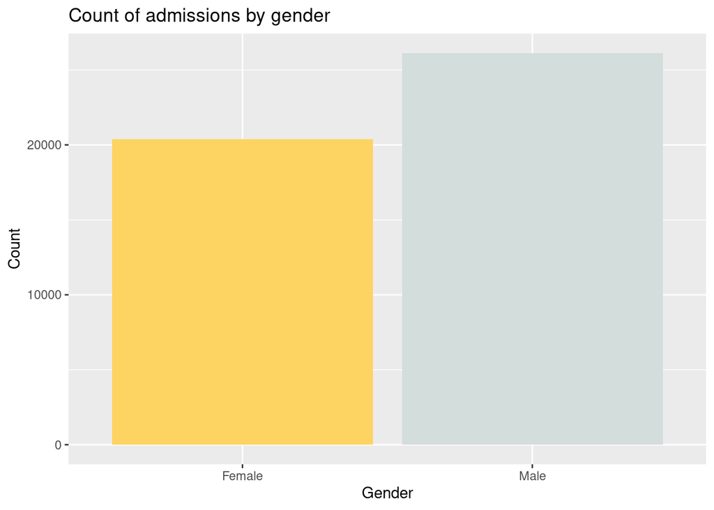

```r
combine %>%
  distinct(SUBJECT_ID, .keep_all = TRUE) %>%
  ggplot() +
  geom_bar(mapping = aes(x = GENDER),
           fill = c("#FDD361","#D3DDDC")) +
  ggtitle("Count of admissions by gender") +
  xlab("Gender") +
  ylab("Count") +
  scale_x_discrete(labels = c("Female", "Male"))
```

There are more male admissions than female admissions.

### Age at admission

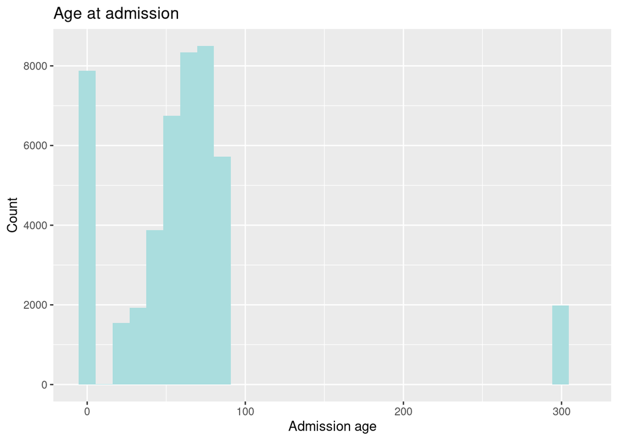

```r
combine %>%
  distinct(SUBJECT_ID, .keep_all = TRUE) %>%
  mutate(adm_age = (as.numeric(ADMITTIME - DOB) / 31557600)) %>%
  ggplot() +
  geom_histogram(mapping = aes(x = adm_age),
                 fill = "#AADDDE") +
  labs(title = "Age at admission",
       x  = "Admission age",
       y = "Count")
```

There are many newborns being seen at the hospital.

Note: there are no patients who are over 300 years old, but rather, their ages are inaccurate due to scrambling the dates in the dataset.

## Q3

`ICUSTAYS.csv` (https://mimic.physionet.org/mimictables/icustays/) contains data about Intensive Care Units (ICU) stays. Summarize following variables using appropriate graphs:

- length of ICU stay
- first ICU unit
- gender
- age

```r
icustays <- read_csv("/home/203bdata/mimic-iii/ICUSTAYS.csv")
combine2 <- inner_join(combine, icustays, by = "SUBJECT_ID")
combine2 %>% print(width = Inf)
```

```
## # A tibble: 116,426 x 37
##    ROW_ID.x SUBJECT_ID HADM_ID.x ADMITTIME           DISCHTIME
##       <int>      <dbl>     <int> <dttm>              <dttm>
##  1       21         22    165315 2196-04-09 12:26:00 2196-04-10 15:54:00
##  2       22         23    152223 2153-09-03 07:15:00 2153-09-08 19:10:00
##  3       22         23    152223 2153-09-03 07:15:00 2153-09-08 19:10:00
##  4       23         23    124321 2157-10-18 19:34:00 2157-10-25 14:00:00
##  5       23         23    124321 2157-10-18 19:34:00 2157-10-25 14:00:00
##  6       24         24    161859 2139-06-06 16:14:00 2139-06-09 12:48:00
##  7       25         25    129635 2160-11-02 02:06:00 2160-11-05 14:55:00
##  8       26         26    197661 2126-05-06 15:16:00 2126-05-13 15:00:00
##  9       27         27    134931 2191-11-30 22:16:00 2191-12-03 14:45:00
## 10       28         28    162569 2177-09-01 07:15:00 2177-09-06 16:00:00
##    DEATHTIME           ADMISSION_TYPE ADMISSION_LOCATION
##    <dttm>              <chr>          <chr>
```

[output cut: 95 more lines]

`combine2` is a dataset that combines data from `ADMISSIONS.csv`, `PATIENTS.csv`, and `ICUSTAYS.csv`.

### Length of ICU stay

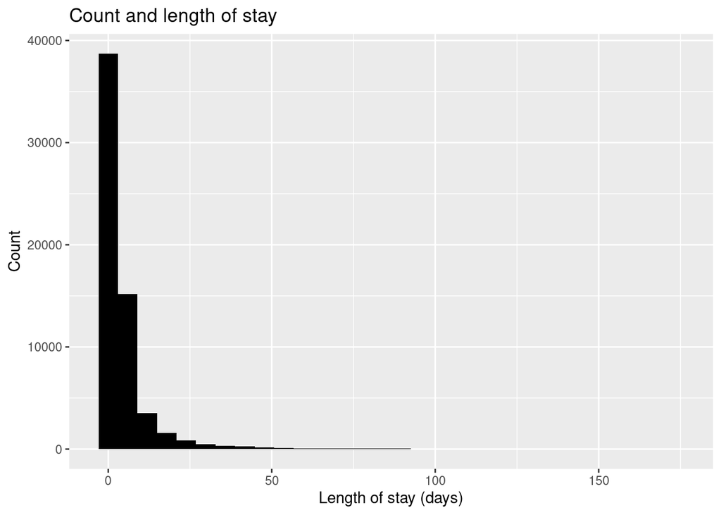

```r
icustays %>%
  ggplot() +
  geom_histogram(mapping = aes(x = LOS),
                 fill = "#000000") +
  labs(title = "Count and length of stay",
       x = "Length of stay (days)",
       y = "Count")
```

The histogram is skewed to the right. However, the majority of patients have a length of stay of 1 day.

### First ICU unit

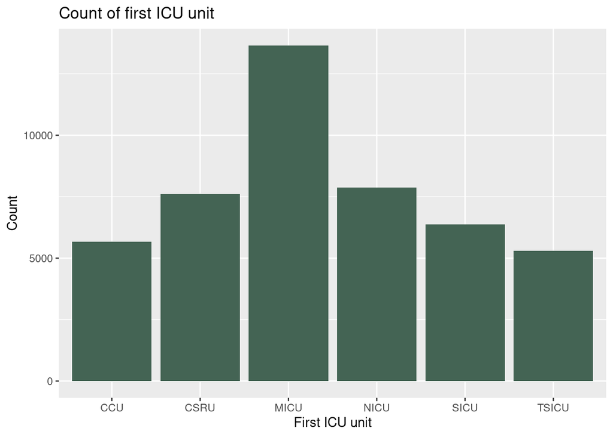

```r
icustays %>%
  distinct(SUBJECT_ID, .keep_all = TRUE) %>%
  ggplot() +
  geom_bar(mapping = aes(x = FIRST_CAREUNIT),
           fill = "#446454") +
  labs(title = "Count of first ICU unit",
       x = "First ICU unit",
       y = "Count")
```

The most common first ICU unit for patients is the MICU (medical intensive care unit).

### Gender

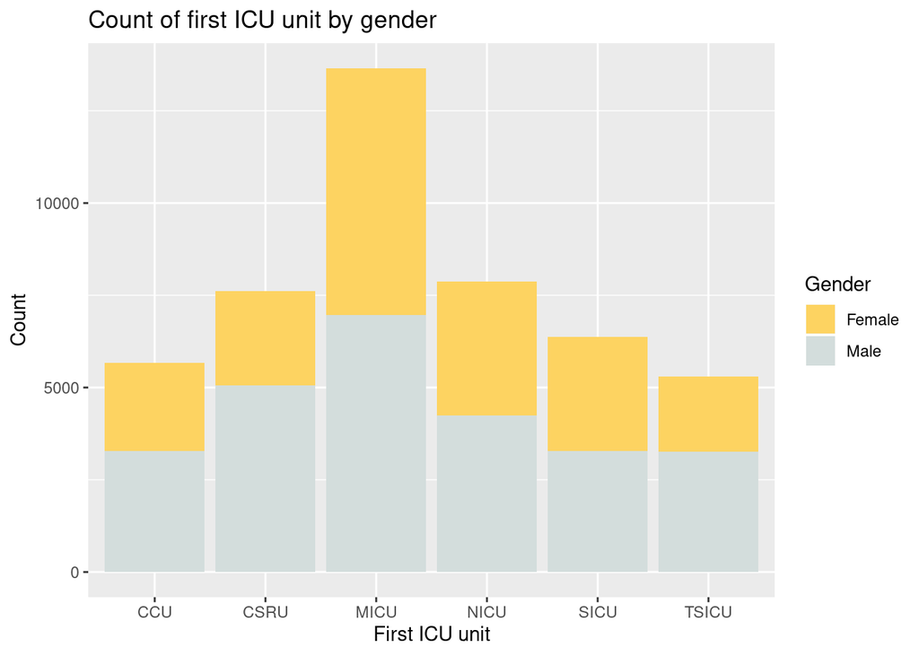

```r
combine2 %>%
  distinct(SUBJECT_ID, .keep_all = TRUE) %>%
  ggplot() +
  geom_bar(mapping = aes(x = FIRST_CAREUNIT, fill = GENDER)) +
  scale_fill_manual(name = "Gender",
                    values = c("#FDD361","#D3DDDC"),
                    labels = c("Female", "Male")) +
  labs(title = "Count of first ICU unit by gender",
       x = "First ICU unit",
       y = "Count")
```

For most of the first ICU units, the proportion of females and males are relatively similar. However, CSRU (cardiac surgery recovery unit) and TSICU (trauma/surgical intensive care unit) have a higher male proportion.

### Age

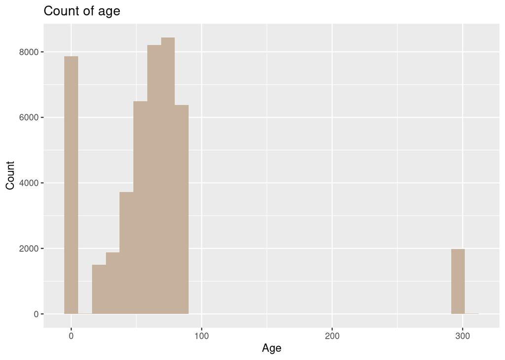

```r
icustays %>%
  arrange(SUBJECT_ID, INTIME) %>%
  distinct(SUBJECT_ID, .keep_all = TRUE) %>%
  left_join(patients, by = "SUBJECT_ID") %>%
  mutate(age = (as.numeric(INTIME - DOB) / 525600)) %>%
  ggplot() +
  geom_histogram(mapping = aes(x = age),
                 fill = "#C6B19C") +
  labs(title = "Count of age",
       x = "Age",
       y = "Count")
```

It appears the age distribution for the the `ICUSTAYS.csv` dataset is similar to the age distribution for the `ADMISSION.csv` dataset. Perhaps many of the hospital admits eventually lead to an ICU stay, resulting in a relatively similar patient population in both datasets.

## Q4

`CHARTEVENTS.csv` (https://mimic.physionet.org/mimictables/chartevents/) contains all the charted data available for a patient. During their ICU stay, the primary repository of a patient’s information is their electronic chart. The `ITEMID` variable indicates a single measurement type in the database. The `VALUE` variable is the value measured for `ITEMID`.

`D_ITEMS.csv` (https://mimic.physionet.org/mimictables/d_items/) is the dictionary for the `ITEMID` in `CHARTEVENTS.csv`. Find potential values of `ITEMID` that correspond to systolic blood pressure, i.e., `LABEL` contains the string `systolic`.

Compile a tibble that contains the first ICU stay of unique patients, with the patient’s demographic information, the first systolic blood pressure measurement during ICU stay, and whether the patient died within 30 days of hospital admission.

```r
chartevents <- read_csv("/home/203bdata/mimic-iii/CHARTEVENTS.csv") %>%
  print(width = Inf)
```

```
## # A tibble: 1,048,575 x 15
##    ROW_ID SUBJECT_ID HADM_ID ICUSTAY_ID ITEMID CHARTTIME     STORETIME      CGID
##     <dbl>      <dbl>   <dbl>      <dbl>  <dbl> <chr>         <chr>         <dbl>
##  1    788         36  165660     241249 223834 5/12/34 12:00 5/12/34 13:56 17525
##  2    789         36  165660     241249 223835 5/12/34 12:00 5/12/34 13:56 17525
##  3    790         36  165660     241249 224328 5/12/34 12:00 5/12/34 12:18 20823
##  4    791         36  165660     241249 224329 5/12/34 12:00 5/12/34 12:19 20823
##  5    792         36  165660     241249 224330 5/12/34 12:00 5/12/34 12:19 20823
##  6    793         36  165660     241249 224331 5/12/34 12:00 5/12/34 12:19 20823
##  7    794         36  165660     241249 224332 5/12/34 12:00 5/12/34 14:44 17525
##  8    795         36  165660     241249 224663 5/12/34 12:00 5/12/34 14:44 17525
##  9    796         36  165660     241249 224665 5/12/34 12:00 5/12/34 14:44 17525
## 10    797         36  165660     241249 220224 5/12/34 12:35 5/12/34 12:38 20889
##     VALUE VALUENUM VALUEUOM WARNING ERROR RESULTSTATUS STOPPED
##     <dbl>    <dbl> <chr>      <dbl> <dbl> <lgl>        <lgl>
##  1  15       15    L/min          0     0 NA           NA
##  2 100      100    <NA>           0     0 NA           NA
##  3   0.37     0.37 <NA>           0     0 NA           NA
##  4   6        6    min            0     0 NA           NA
##  5   2.5      2.5  <NA>           0     0 NA           NA
##  6   0        0    ml/hr          0     0 NA           NA
##  7   3        3    <NA>           0     0 NA           NA
##  8   8        8    <NA>           0     0 NA           NA
##  9   1.11     1.11 <NA>           0     0 NA           NA
## 10  58       58    mmHg           1     0 NA           NA
## # … with 1,048,565 more rows
```

```r
d_items <- read_csv("/home/203bdata/mimic-iii/D_ITEMS.csv") %>%
  print(width = Inf)
```

```
## # A tibble: 12,487 x 10
##    ROW_ID ITEMID LABEL                                       ABBREVIATION
##     <dbl>  <dbl> <chr>                                       <lgl>
##  1    457    497 Patient controlled analgesia (PCA) [Inject] NA
##  2    458    498 PCA Lockout (Min)                           NA
##  3    459    499 PCA Medication                              NA
##  4    460    500 PCA Total Dose                              NA
##  5    461    501 PCV Exh Vt (Obser)                          NA
##  6   1157    927 Allergy 2                                   NA
##  7   1158    930 Ext                                         NA
##  8   1159    935 Allergy 3                                   NA
##  9   1160    938 blood cultures                              NA
## 10   1161    940 trach care                                  NA
##    DBSOURCE LINKSTO     CATEGORY UNITNAME PARAM_TYPE CONCEPTID
##    <chr>    <chr>       <chr>    <lgl>    <lgl>      <lgl>
##  1 carevue  chartevents <NA>     NA       NA         NA
##  2 carevue  chartevents <NA>     NA       NA         NA
##  3 carevue  chartevents <NA>     NA       NA         NA
##  4 carevue  chartevents <NA>     NA       NA         NA
##  5 carevue  chartevents <NA>     NA       NA         NA
##  6 carevue  chartevents <NA>     NA       NA         NA
##  7 carevue  chartevents <NA>     NA       NA         NA
##  8 carevue  chartevents <NA>     NA       NA         NA
##  9 carevue  chartevents <NA>     NA       NA         NA
## 10 carevue  chartevents <NA>     NA       NA         NA
## # … with 12,477 more rows
```

```r
systolic <- d_items %>%
  filter(grepl("systolic", LABEL)) %>%
  print(width = Inf)
```

```
## # A tibble: 5 x 10
##   ROW_ID ITEMID LABEL                                ABBREVIATION DBSOURCE
##    <dbl>  <dbl> <chr>                                <lgl>        <chr>
## 1  14629 226850 RV systolic pressure(PA Line)        NA           metavision
## 2  14631 226852 PA systolic pressure(PA Line)        NA           metavision
## 3  12716 220050 Arterial Blood Pressure systolic     NA           metavision
## 4  12721 220059 Pulmonary Artery Pressure systolic   NA           metavision
## 5  12734 220179 Non Invasive Blood Pressure systolic NA           metavision
##   LINKSTO     CATEGORY            UNITNAME PARAM_TYPE CONCEPTID
##   <chr>       <chr>               <lgl>    <lgl>      <lgl>
## 1 chartevents PA Line Insertion   NA       NA         NA
## 2 chartevents PA Line Insertion   NA       NA         NA
## 3 chartevents Routine Vital Signs NA       NA         NA
## 4 chartevents Hemodynamics        NA       NA         NA
## 5 chartevents Routine Vital Signs NA       NA         NA
```

There are five items in the `LABEL` variable that measure systolic pressure.

```r
sys_chartevents <- chartevents %>%
  filter(ITEMID %in% systolic$ITEMID) %>%
  arrange(SUBJECT_ID, CHARTTIME) %>%
  print(width = Inf)
```

```
## # A tibble: 75,642 x 15
##    ROW_ID SUBJECT_ID HADM_ID ICUSTAY_ID ITEMID CHARTTIME      STORETIME
##     <dbl>      <dbl>   <dbl>      <dbl>  <dbl> <chr>          <chr>
##  1      6         23  124321     234044 220050 10/21/57 12:15 10/21/57 12:15
##  2     19         23  124321     234044 220050 10/21/57 13:00 10/21/57 14:09
##  3     25         23  124321     234044 220050 10/21/57 14:00 10/21/57 14:09
##  4     47         23  124321     234044 220050 10/21/57 15:00 10/21/57 15:44
##  5     54         23  124321     234044 220050 10/21/57 16:17 10/21/57 16:24
##  6     60         23  124321     234044 220050 10/21/57 17:00 10/21/57 17:03
##  7     69         23  124321     234044 220050 10/21/57 18:03 10/21/57 18:19
##  8     72         23  124321     234044 220050 10/21/57 19:00 10/21/57 19:12
##  9     79         23  124321     234044 220050 10/21/57 20:00 10/21/57 20:48
## 10     86         23  124321     234044 220050 10/21/57 21:00 10/21/57 21:43
##     CGID VALUE VALUENUM VALUEUOM WARNING ERROR RESULTSTATUS STOPPED
##    <dbl> <dbl>    <dbl> <chr>      <dbl> <dbl> <lgl>        <lgl>
##  1 16978   181      181 mmHg           0     0 NA           NA
##  2 16978   133      133 mmHg           0     0 NA           NA
##  3 16978   132      132 mmHg           0     0 NA           NA
##  4 16978   145      145 mmHg           0     0 NA           NA
##  5 16978   152      152 mmHg           0     0 NA           NA
##  6 16978   138      138 mmHg           0     0 NA           NA
##  7 16978   156      156 mmHg           0     0 NA           NA
##  8 16978   132      132 mmHg           0     0 NA           NA
##  9 19050   140      140 mmHg           0     0 NA           NA
## 10 19050    66       66 mmHg           0     0 NA           NA
## # … with 75,632 more rows
```

`sys_chartevents` is a subset of `chartevents` that only includes rows that measure systolic pressure.

```r
icustays %>%
  print(width = Inf)
```

```
## # A tibble: 61,532 x 12
##    ROW_ID SUBJECT_ID HADM_ID ICUSTAY_ID DBSOURCE FIRST_CAREUNIT LAST_CAREUNIT
##     <dbl>      <dbl>   <dbl>      <dbl> <chr>    <chr>          <chr>
##  1    365        268  110404     280836 carevue  MICU           MICU
##  2    366        269  106296     206613 carevue  MICU           MICU
##  3    367        270  188028     220345 carevue  CCU            CCU
##  4    368        271  173727     249196 carevue  MICU           SICU
##  5    369        272  164716     210407 carevue  CCU            CCU
##  6    370        273  158689     241507 carevue  MICU           MICU
##  7    371        274  130546     254851 carevue  MICU           MICU
##  8    372        275  129886     219649 carevue  CCU            CCU
##  9    373        276  135156     206327 carevue  CCU            CCU
## 10    374        277  171601     272866 carevue  NICU           NICU
##    FIRST_WARDID LAST_WARDID INTIME              OUTTIME               LOS
##           <dbl>       <dbl> <dttm>              <dttm>              <dbl>
##  1           52          52 2198-02-14 23:27:38 2198-02-18 05:26:11 3.25
##  2           52          52 2170-11-05 11:05:29 2170-11-08 17:46:57 3.28
##  3           57          57 2128-06-24 15:05:20 2128-06-27 12:32:29 2.89
##  4           52          23 2120-08-07 23:12:42 2120-08-10 00:39:04 2.06
##  5           57          57 2186-12-25 21:08:04 2186-12-27 12:01:13 1.62
##  6           52          52 2141-04-19 06:12:05 2141-04-20 17:52:11 1.49
##  7           12          12 2114-06-28 22:28:44 2114-07-07 18:01:16 8.81
##  8            7           7 2170-10-07 11:28:53 2170-10-14 14:38:07 7.13
##  9           57          57 2147-11-20 09:02:23 2147-11-21 17:08:52 1.34
## 10           56          56 2132-10-21 21:11:46 2132-10-22 14:44:48 0.731
## # … with 61,522 more rows
```

```r
icustays %>%
  arrange(SUBJECT_ID, ICUSTAY_ID, INTIME) %>%
  distinct(ICUSTAY_ID, .keep_all = TRUE)
```

```
## # A tibble: 61,532 x 12
##    ROW_ID SUBJECT_ID HADM_ID ICUSTAY_ID DBSOURCE FIRST_CAREUNIT LAST_CAREUNIT
##     <dbl>      <dbl>   <dbl>      <dbl> <chr>    <chr>          <chr>
##  1      1          2  163353     243653 carevue  NICU           NICU
##  2      2          3  145834     211552 carevue  MICU           MICU
##  3      3          4  185777     294638 carevue  MICU           MICU
##  4      4          5  178980     214757 carevue  NICU           NICU
##  5      5          6  107064     228232 carevue  SICU           SICU
##  6      7          7  118037     236754 carevue  NICU           NICU
##  7      6          7  118037     278444 carevue  NICU           NICU
##  8      8          8  159514     262299 carevue  NICU           NICU
##  9      9          9  150750     220597 carevue  MICU           MICU
## 10     10         10  184167     288409 carevue  NICU           NICU
## # … with 61,522 more rows, and 5 more variables: FIRST_WARDID <dbl>,
## #   LAST_WARDID <dbl>, INTIME <dttm>, OUTTIME <dttm>, LOS <dbl>
```

I wanted to check whether the `icustays` dataset had only unique ICU visits, which it does since both datasets contain the same number of rows.

```r
new_admissions <- admissions %>%
  mutate(death_time = as.numeric(DEATHTIME - ADMITTIME)) %>%
  subset(death_time <= 2592000) %>%
  dplyr::rename(SUBJECT_ID.x = SUBJECT_ID)
```

`new_admissions` is a subset of `admissions` depending on whether the patient died within 30 days of hospital admissions (2,592,000 seconds).

```r
tibble <- icustays %>%
  # Finds unique ICU stays and selects the earliest one
  arrange(SUBJECT_ID, ICUSTAY_ID, INTIME) %>%
  distinct(ICUSTAY_ID, .keep_all = TRUE) %>%
  right_join(sys_chartevents, by = "ICUSTAY_ID") %>%
  # Sort by SUBJECT_ID and then CHARTTIME
  arrange(SUBJECT_ID.x, CHARTTIME) %>%
  # Selects the first ICU stay
  distinct(ICUSTAY_ID, .keep_all =  TRUE) %>%
  left_join(systolic, by = "ITEMID") %>%
  left_join(new_admissions, by = "SUBJECT_ID.x") %>%
  select(SUBJECT_ID.x, FIRST_CAREUNIT, VALUE, VALUEUOM,
         LABEL, INSURANCE:ETHNICITY, death_time) %>%
  dplyr::rename(SUBJECT_ID = SUBJECT_ID.x, DEATH_30D = death_time) %>%
  mutate(DEATH_30D = as.numeric(DEATH_30D))

tibble$DEATH_30D[is.na(tibble$DEATH_30D)] <- 0
tibble$DEATH_30D[tibble$DEATH_30D > 0] <- 1

tibble %>%
  print(width = Inf)
```

```
## # A tibble: 808 x 11
##    SUBJECT_ID FIRST_CAREUNIT VALUE VALUEUOM LABEL
##         <dbl> <chr>          <dbl> <chr>    <chr>
##  1         23 SICU             181 mmHg     Arterial Blood Pressure systolic
##  2         34 CCU              169 mmHg     Non Invasive Blood Pressure systolic
##  3         36 MICU             118 mmHg     Non Invasive Blood Pressure systolic
##  4         85 MICU             166 mmHg     Non Invasive Blood Pressure systolic
##  5        107 MICU             155 mmHg     Non Invasive Blood Pressure systolic
##  6        107 MICU             111 mmHg     Non Invasive Blood Pressure systolic
##  7        109 SICU             171 mmHg     Non Invasive Blood Pressure systolic
##  8        109 MICU             169 mmHg     Non Invasive Blood Pressure systolic
##  9        109 SICU             168 mmHg     Non Invasive Blood Pressure systolic
## 10        109 MICU             192 mmHg     Non Invasive Blood Pressure systolic
##    INSURANCE LANGUAGE RELIGION      MARITAL_STATUS ETHNICITY
##    <chr>     <chr>    <chr>         <chr>          <chr>
```

[output cut: 23 more lines]

I sorted `icustays` by `INTIME`, so I could select the first ICU stay for each unique ICU stay. I right-joined `icustays` with `sys_chartevents` (the subsetted chartevents dataset that only contained rows with a systolic pressure reading). I arranged by `SUBJECT_ID.x` and `CHARTTIME` to make sure the first systolic pressure reading was first and then selected only the first reading. I then left-joined with `systolic` to add the `LABEL` column. I left-joined with `new_admissions` to include the `death_time` variable.

As a result, there are 808 unique ICU stays. Some patients may have multiple unique ICU stays. For example, Subject 109 has 27 unique ICU stays.

Note: A value of 1 in the `DEATH_30D` column means the patient died within 30 days of hospital admission